[deita](https://deita.eu/) [About](https://deita.eu/about.html)

# D6 · The Fancy Tax

Capstone dossier · which dishes carry the upscale premium, and which refuse to

Author

Dei M. Elurbe

Published

July 10, 2026

**Dossier, not the essay.** Backstage layer for technical readers; the capstone essay is the general-audience artifact. Corpus: **Snapshot · June 2026**, ~900 priced venues, roughly 4 in 10 of Amsterdam’s ~2,028 restaurants.

## The verdict

Upscale venues charge more, but not the way people assume, and they say “upscale” in two different typefaces. Menu fanciness speaks **two text registers, and both carry a premium**: the florid register (wordy descriptions) adds **+2.7% per step of wordiness** (95% CI +0.7 to +4.8), and the terse fine-dining register (ingredient-list menus, “word · word · word”) adds **+7.3%** of its own (95% CI +1.2 to +13.9). The terse register was the project leader’s catch: the original wordiness proxy misfiled exactly the venues that stopped writing sentences, and separating them out made the wordiness effect *stronger* (Decision #42).

The real finding is the heterogeneity underneath: the premium is **not a flat markup**, it concentrates in specific dish-types. Across 135 cells (florid register; terse venues set aside) the per-cell fancy tax runs from −21% to +36% per wordiness step (median +4%, interquartile range −2% to +9%). The pattern in *which* dishes carry it is the insight: **the premium lives where there is no reference price, and disappears where there is one.** Rice dishes (+20 to +24%) and bread-and-dips starters (+20%) ride it hard; the nominal top cell (generic meat sides, +36%) is retired below as a composition artifact after a dish-level audit. The commodities every diner can price from memory barely move: carpaccio +1%, fish of the day +2% on 860 dishes. An upscale venue extracts its margin through menu *composition* first (dossier D4) and through the fuzzy-priced corners of the menu second; it does not visibly mark up the dishes you would notice.

One caveat leads everything here, per the data-layer audit: **per-cell estimates are noisy.** Only 56 of the 135 cells individually resolve a nonzero effect at 95% confidence (50 positive, 6 negative). The aggregates and the *pattern* are solid; any single cell’s number should be read with its interval.

## Why the obvious approach lies

“Fancy places are expensive” is mostly composition: they serve rib-eyes and raw bars, not bitterballen. D4 removes that channel and finds the same-dish premium is small: +2.7% per standard deviation (SD) of florid wordiness, +7.3% for the terse ingredient-list register. This dossier asks the next question: is that premium spread evenly, or does it hide in particular dishes? A flat markup and a targeted one look identical in the aggregate; only within-cell slopes can tell them apart.

## The instrument: measuring “fancy” without touching price

Venue fanciness is read from menu **text**, never from price, so a fancy-tax estimate cannot be circular. And the text turns out to speak two registers:

- **The florid register** is proxied by wordiness: the average character length of dish descriptions, log-scaled and standardized. A plain café writes “kipsaté”; this register writes “free-range corn chicken saté, house-made peanut sauce, pickled cucumber”.
- **The terse register** is the modern fine-dining idiom: short, separator-built ingredient lists with no function words (“Noordzee krab → groene peper, lavasmayonaise, courgette”). Florid prose needs prepositions; ingredient lists refuse them, which makes the register machine-detectable. A venue is flagged terse when at least half of its described dishes match and descriptions cover at least 30% of its menu; 85 of 849 venues qualify.

The wordiness proxy alone misfiles the terse venues at the *plain* end of the scale, which attenuated the original estimate. Adoption of the two-register model went through pre-committed probes: the terse premium is sign-stable across a 3×3 grid of detector cuts, survives within all-rounder venues alone (+24%), and moves the café and area coefficients by less than a point. The per-cell slopes below are computed on florid-register venues only, so that the terse register cannot contaminate them the way it contaminated the aggregate.

## What it found

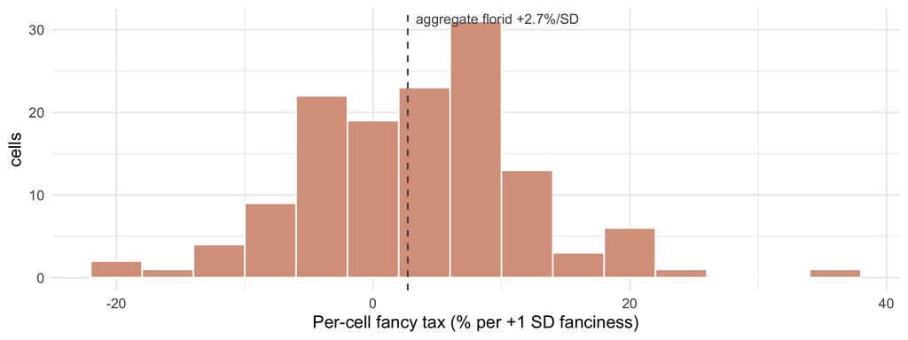

Figure 1: The distribution of per-cell fancy-tax slopes (135 cells, florid register). The aggregate same-dish effect (+2.7%/SD, dashed) sits near the median; the spread around it is the finding: some dish-types absorb the upscale premium, most do not.

```r
suppressPackageStartupMessages({library(dplyr); library(ggplot2)})

ft <- readr::read_csv("_data/fancytax_ci.csv", show_col_types = FALSE)

ggplot(ft, aes(tax_pct)) +
  geom_histogram(binwidth = 4, fill = "#d9a08a", colour = "white") +
  geom_vline(xintercept = 2.7, linetype = "dashed", colour = "grey30") +
  annotate("text", x = 2.7, y = Inf, label = "aggregate florid +2.7%/SD",
           hjust = -0.05, vjust = 1.5, size = 3.1, colour = "grey30") +
  labs(x = "Per-cell fancy tax (% per +1 SD fanciness)", y = "cells") +
  theme_minimal()
```

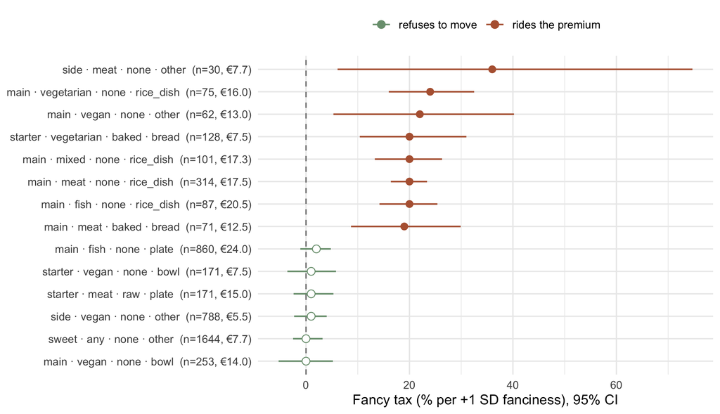

Figure 2: The extremes, with 95% confidence intervals. Top: the dish-types that nominally ride the upscale premium hardest (the generic-meat-sides cell at +36% is retired as a composition artifact; see text). Bottom: the commodities that refuse to move. Filled dots mark cells whose interval excludes zero; open dots are individually unresolved.

```r
top  <- ft |> arrange(desc(tax_pct)) |> head(8)
flat <- ft |> filter(n >= 100) |> arrange(abs(tax_pct)) |> head(6)

sel <- bind_rows(mutate(top, group = "rides the premium"),
                 mutate(flat, group = "refuses to move")) |>
  mutate(resolved = ci_lo > 0 | ci_hi < 0,
         label = sprintf("%s  (n=%d, €%.1f)", cell, n, typical))

ggplot(sel, aes(x = tax_pct, y = reorder(label, tax_pct), colour = group)) +
  geom_vline(xintercept = 0, linetype = "dashed", colour = "grey50") +
  geom_linerange(aes(xmin = ci_lo, xmax = ci_hi), linewidth = .6) +
  geom_point(aes(shape = resolved), size = 2.6, fill = "white") +
  scale_shape_manual(values = c(`TRUE` = 16, `FALSE` = 21), guide = "none") +
  scale_colour_manual(values = c("rides the premium" = "#b5623f",
                                 "refuses to move" = "#7a9e7e"), name = NULL) +
  labs(x = "Fancy tax (% per +1 SD fanciness), 95% CI", y = NULL) +
  theme_minimal() + theme(legend.position = "top")
```

**One cell did not survive its audit, and retiring it is the method working.** The nominal top slope, generic meat sides (`side · meat · none · other`, +36%, n=30), was dish-audited after the leader flagged it (2026-07-02): its plain-venue end is snackbar satés (€2.75) and lemper; its fancy-venue end is izakaya bites (aburi chashu, tebasaki) and composed spring rolls. That slope compares *different products* sharing one catch-all coordinate, not the same side dish marked up. The general lesson: **`other`-form catch-all cells are composition-sensitive**, and their slopes should be read as descriptions of what fancier venues *stock*, not what they charge for the same item. The robust examples (bread, rice dishes) are product-coherent under the same audit; they lead the reading above.

**Where the desserts went.** Under the old one-register proxy, plated desserts read +24% per fanciness step. Under the two-register model that cell is too thin to estimate: enough of its dishes come from terse-register venues that, once those venues carry their own +7.3% flag, the florid-only remainder falls below the reporting threshold. The dessert premium is real, but it is a *fine-dining-register* phenomenon (the venues charging it are the ones writing “word · word · word”) rather than a wordiness slope. The remaining sweet cells, at everyday venues, are flat (−6% to +7%).

## The stress-test battery

[output not shown]

## Lineage

- **Method + brief:** `docs/m5_typical_menus.md` (§5 deliverable 2); audit record `docs/m5_data_audit_findings.md` (finding 7: lead with uncertainty).
- **Code:** `R/52_dish_atlas_context.R` (two-register model + the canonical slopes); `_prep/fancytax_ci.R` (exact replication + confidence intervals); `_prep/terse_fancy_test.R` + `_prep/terse_adoption_probes.R` (the register diagnostic and its pre-committed adoption gate).
- **Data:** `dish_atlas_context_effects.csv`, `dish_atlas_fancytax.csv` (canonical), `_data/fancytax_ci.csv` (with CIs), `_data/terse_fancy.csv`.
- **Journal trail:** `2026-06-30_001` (context effects design), `2026-06-30_005/_006` (audit + the uncertainty carry-forward), `2026-07-02_004/_005` (the terse register: diagnosis, probes, canonical adoption, Decision #42).
- **Sources:** restaurant websites (menus), OpenStreetMap (venue universe). All open data. **Snapshot · June 2026.**